# Practical Bayesian Modeling with Stan and brms

Author

Masatoshi Katabuchi

Published

June 13, 2025

```r
library(brms)
library(cmdstanr)
library(tidyverse)
library(bayesplot)
library(patchwork)
cmdstanr::set_cmdstan_path("/opt/cmdstan/cmdstan-2.36.0")
```

```
CmdStan path set to: /opt/cmdstan/cmdstan-2.36.0
```

```r
theme_set(theme_bw())
```

# 1 Normal model

$$y_i \sim N(\mu, \sigma)$$

## 1.1 Dummy data

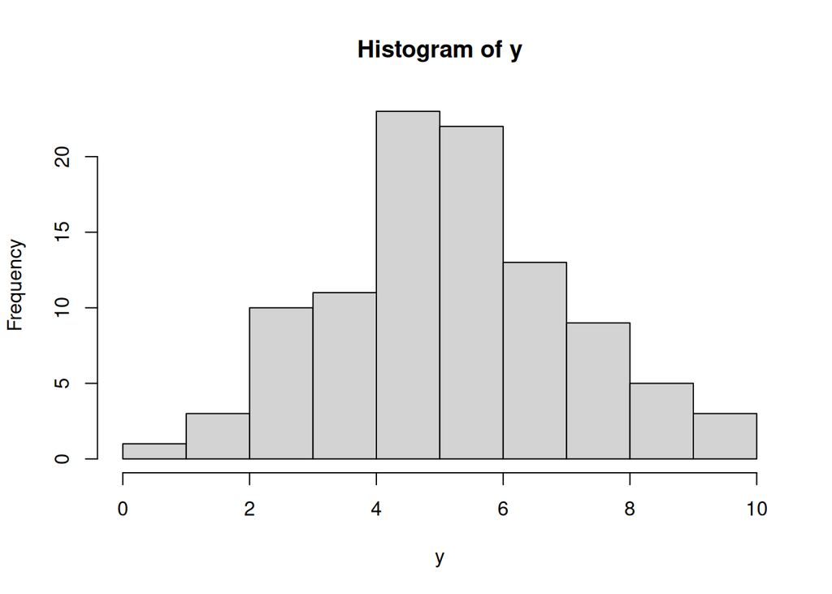

```r
set.seed(123)
n <- 100
mu <- 5
sigma <- 2
y <- rnorm(n, mean = mu, sd = sigma)

hist(y)
```

```r
normal_list <- list(
  y = y,
  N = length(y)
)

normal_df <- tibble(
  y = y,
  N = length(y)
)
```

## 1.2 Stan

`stan/normal.stan`

```stan
 data {
  int<lower=0> N;
  vector[N] y;
}

parameters {
  real mu;
  real<lower=0> sigma;
}

model {
  y ~ normal(mu, sigma);
  mu ~ normal(0, 10);
  sigma ~ cauchy(0, 2.5);
}
```

`stan/normal_vague.stan`

```stan
 data {
  int<lower=0> N;
  vector[N] y;
}

parameters {
  real mu;
  real<lower=0> sigma;
}

model {
  y ~ normal(mu, sigma);
  mu ~ normal(0, 1e+4); // Vague prior for mu
  sigma ~ normal(0, 1e+4); // Vague prior for sigma
}
```

```r
normal_mod <- cmdstan_model("stan/normal.stan")
normal_vague_mod <- cmdstan_model("stan/normal_vague.stan")
```

```r
normal_fit <- normal_mod$sample(
  data = normal_list,
  seed = 123,
  chains = 4,
  parallel_chains = 4,
  iter_warmup = 1000, # number of warmup iterations
  iter_sampling = 1000, # number of sampling iterations
  refresh = 500 # print update every 500 iters
)
```

```
Running MCMC with 4 parallel chains...

Chain 1 Iteration:    1 / 2000 [  0%]  (Warmup)
Chain 1 Iteration:  500 / 2000 [ 25%]  (Warmup)
Chain 1 Iteration: 1000 / 2000 [ 50%]  (Warmup)
Chain 1 Iteration: 1001 / 2000 [ 50%]  (Sampling)
Chain 1 Iteration: 1500 / 2000 [ 75%]  (Sampling)
Chain 1 Iteration: 2000 / 2000 [100%]  (Sampling)
Chain 2 Iteration:    1 / 2000 [  0%]  (Warmup)
Chain 2 Iteration:  500 / 2000 [ 25%]  (Warmup)
Chain 2 Iteration: 1000 / 2000 [ 50%]  (Warmup)
Chain 2 Iteration: 1001 / 2000 [ 50%]  (Sampling)
Chain 2 Iteration: 1500 / 2000 [ 75%]  (Sampling)
Chain 2 Iteration: 2000 / 2000 [100%]  (Sampling)
Chain 3 Iteration:    1 / 2000 [  0%]  (Warmup)
Chain 3 Iteration:  500 / 2000 [ 25%]  (Warmup)
Chain 3 Iteration: 1000 / 2000 [ 50%]  (Warmup)
Chain 3 Iteration: 1001 / 2000 [ 50%]  (Sampling)
Chain 3 Iteration: 1500 / 2000 [ 75%]  (Sampling)
Chain 3 Iteration: 2000 / 2000 [100%]  (Sampling)
Chain 4 Iteration:    1 / 2000 [  0%]  (Warmup)
Chain 4 Iteration:  500 / 2000 [ 25%]  (Warmup)
Chain 4 Iteration: 1000 / 2000 [ 50%]  (Warmup)
Chain 4 Iteration: 1001 / 2000 [ 50%]  (Sampling)
Chain 4 Iteration: 1500 / 2000 [ 75%]  (Sampling)
Chain 4 Iteration: 2000 / 2000 [100%]  (Sampling)
Chain 1 finished in 0.0 seconds.
Chain 2 finished in 0.0 seconds.
Chain 3 finished in 0.0 seconds.
Chain 4 finished in 0.0 seconds.

All 4 chains finished successfully.
Mean chain execution time: 0.0 seconds.
Total execution time: 0.2 seconds.
```

```r
normal_vague_fit <- normal_vague_mod$sample(
  data = normal_list,
  seed = 123,
  chains = 4,
  parallel_chains = 4,
  refresh = 500 # print update every 500 iters
)
```

[output not shown]

### 1.2.1 Summary

We use this to write in manuscripts and for diagnostics.

```r
normal_fit$summary()
```

```
# A tibble: 3 × 10
  variable    mean  median    sd   mad      q5     q95  rhat ess_bulk ess_tail
  <chr>      <dbl>   <dbl> <dbl> <dbl>   <dbl>   <dbl> <dbl>    <dbl>    <dbl>
1 lp__     -111.   -110.   0.973 0.703 -113.   -110.    1.00    1644.    2396.
2 mu          5.18    5.18 0.179 0.183    4.88    5.47  1.00    2858.    2485.
3 sigma       1.84    1.83 0.132 0.128    1.64    2.07  1.00    2871.    2288.
```

- `lp__`: log posterior.
  - $\text{log}\; p(\theta \mid \text{data}) \propto \text{log}\; p(\text{data} \mid \theta) + \text{log}\; p(\theta)$
- `rhat` (Gelman-Rubin statistic): should be close to 1.
  - Measures the convergence of the chains.
  - `rhat` > 1.1: Definitely bad.
  - 1.01 < `rhat` < 1.1: Suspicous.
  - `rhat` <= 1.01: Good.
- `ess_bulk` and `ess_tail`: Effective sample size for bulk and tail of the posterior distribution.
  - `ess_bulk`: sampling efficiency for the bulk posteriors (e.g., mean, SD).
  - `ess_tail`: sampling efficiency for the tails (e.g., quantiles like 2.5%, 97.5%).
  - `ess_bulk`, `ess_tail` > 400: Good.

### 1.2.2 Draws (posterior samples)

For each parameter, we have 1000 iterations $\times$ 4 chains = 4000 posteriors. We use this for visualization and diagnostics.

```r
normal_fit$draws()
```

```
# A draws_array: 1000 iterations, 4 chains, and 3 variables
, , variable = lp__

         chain
iteration    1    2    3    4
        1 -110 -110 -111 -111
        2 -110 -110 -110 -110
        3 -110 -110 -111 -111
        4 -110 -110 -111 -111
        5 -110 -110 -110 -111

, , variable = mu

         chain
iteration   1   2   3   4
        1 5.1 5.1 5.0 5.2
        2 5.2 5.1 5.3 5.0
        3 5.1 5.2 4.9 5.1
        4 5.2 5.2 5.5 5.2
        5 5.2 5.0 5.4 5.2

, , variable = sigma

         chain
iteration   1   2   3   4
        1 1.9 1.8 1.6 2.0
        2 1.8 1.9 1.8 1.7
        3 1.9 1.9 1.7 1.6
        4 1.8 1.7 1.9 2.1
        5 1.8 1.8 1.8 1.6

# ... with 995 more iterations
```

Trace plots for diagnosing convergence and mixing of the chains.

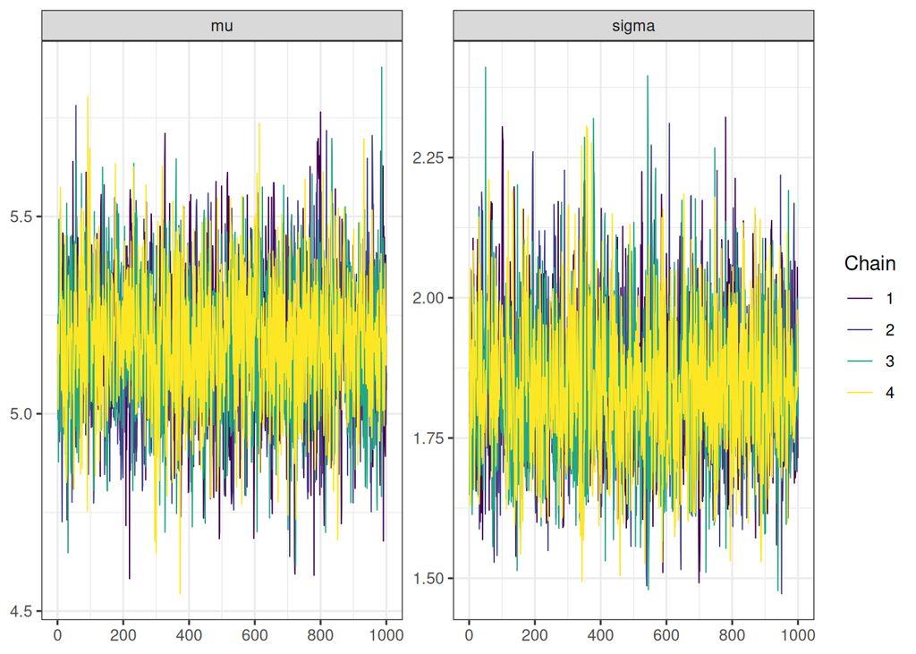

```r
normal_draws <- as_draws_df(normal_fit$draws())

color_scheme_set("viridis")
mcmc_trace(normal_draws, pars = c("mu", "sigma"))
```

Histograms of the posterior distributions of the parameters.

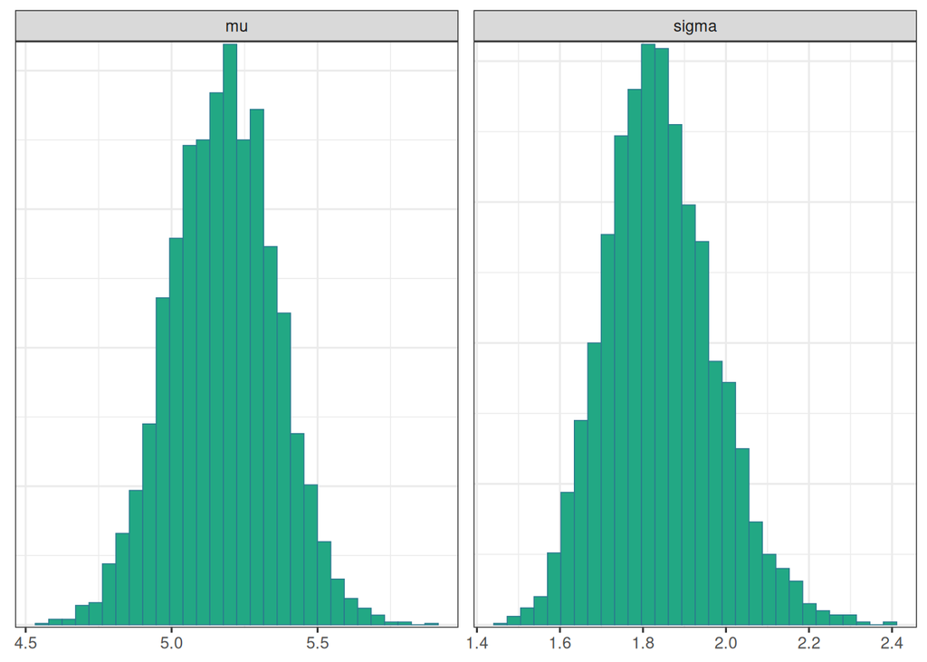

```r
mcmc_hist(normal_draws, pars = c("mu", "sigma"))
```

### 1.2.3 Diagnostic summary

```r
normal_fit$diagnostic_summary()
```

```
$num_divergent
[1] 0 0 0 0

$num_max_treedepth
[1] 0 0 0 0

$ebfmi
[1] 1.029135 1.091294 1.118529 1.142636
```

- `num_divergent`: indicates the number of iterations (sampling transitions) where the Hamiltonian trajectory failed — meaning Stan detected a **divergent transition**.
  - Even 1-2 divergent transitions suggest that model may not be reaiable, especially in hierachical models.
  - We need reparamaterization or increase `adapt_delta` to make the sampler take smaller steps.
- `num_max_treedepth`: indicates the number of iterations where there are not enough leafprog steps.
  - This can indicate that the model is complex or that the priors are too tight.
  - We can increase `max_treedepth` to allow more steps, but this can increase the computation time.
- `ebfmi`: Energy-Bayesian Fraction of Missing Information
  - Measures whether the resampled momentum generates enough variation in energy to explore the posterior efficiently.
  - Low `ebfmi` means the sampler may be stuck in tight regions and exploring poorly, even if Rhat and ESS look fine.
  - Guidelines:
    - `ebfmi` < 0.3: Bad
    - 0.3 < `ebfmi` <= 1: Acceptable
    - `ebfmi` >= 1: Good

## 1.3 `brms`

```r
normal_fit_brm0 <- brm(y ~ 1, family = gaussian(), data = normal_df)
```

```r
normal_fit_brm <- brm(
  y ~ 1,
  family = gaussian(),
  data = normal_df,
  prior = c(
    prior(normal(0, 5), class = "Intercept"),
    prior(cauchy(0, 2.5), class = "sigma")
  )
)
```

### 1.3.1 Summary

```r
summary(normal_fit_brm)
```

```
 Family: gaussian
  Links: mu = identity; sigma = identity
Formula: y ~ 1
   Data: normal_df (Number of observations: 100)
  Draws: 4 chains, each with iter = 2000; warmup = 1000; thin = 1;
         total post-warmup draws = 4000

Regression Coefficients:
          Estimate Est.Error l-95% CI u-95% CI Rhat Bulk_ESS Tail_ESS
Intercept     5.18      0.18     4.81     5.54 1.00     3473     2500

Further Distributional Parameters:
      Estimate Est.Error l-95% CI u-95% CI Rhat Bulk_ESS Tail_ESS
sigma     1.85      0.13     1.62     2.13 1.00     3265     2275

Draws were sampled using sampling(NUTS). For each parameter, Bulk_ESS
and Tail_ESS are effective sample size measures, and Rhat is the potential
scale reduction factor on split chains (at convergence, Rhat = 1).
```

### 1.3.2 Draws (posterior samples)

```r
normal_draws_brm <- posterior::as_draws_df(normal_fit_brm)
normal_draws_brm
```

```
# A draws_df: 1000 iterations, 4 chains, and 5 variables
   b_Intercept sigma Intercept lprior lp__
1          5.1   2.2       5.1   -5.0 -209
2          5.0   1.9       5.0   -4.8 -206
3          5.4   1.9       5.4   -4.9 -207
4          4.8   1.9       4.8   -4.8 -208
5          5.4   1.8       5.4   -4.9 -207
6          5.1   1.9       5.1   -4.9 -206
7          5.2   1.8       5.2   -4.9 -206
8          5.0   1.9       5.0   -4.9 -207
9          5.3   1.8       5.3   -4.9 -206
10         5.4   2.1       5.4   -5.0 -208
# ... with 3990 more draws
# ... hidden reserved variables {'.chain', '.iteration', '.draw'}
```

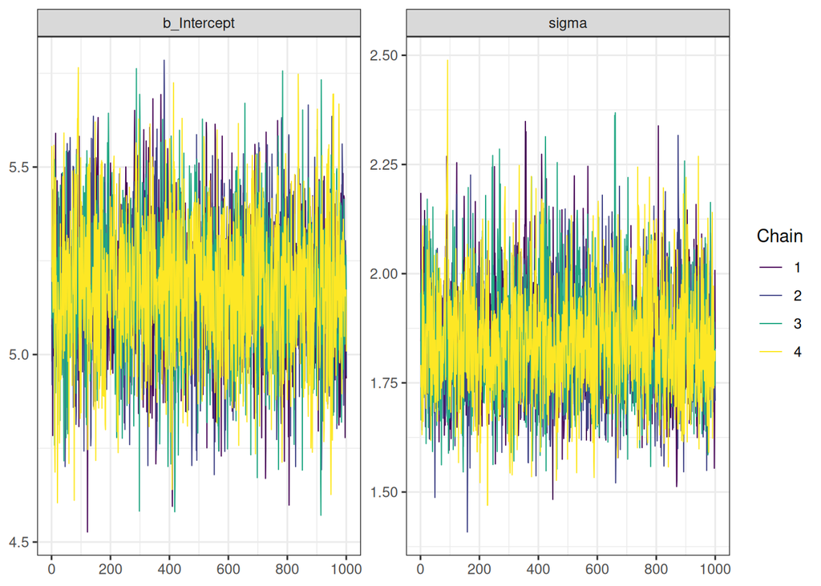

```r
mcmc_trace(normal_draws_brm, pars = c("b_Intercept", "sigma"))
```

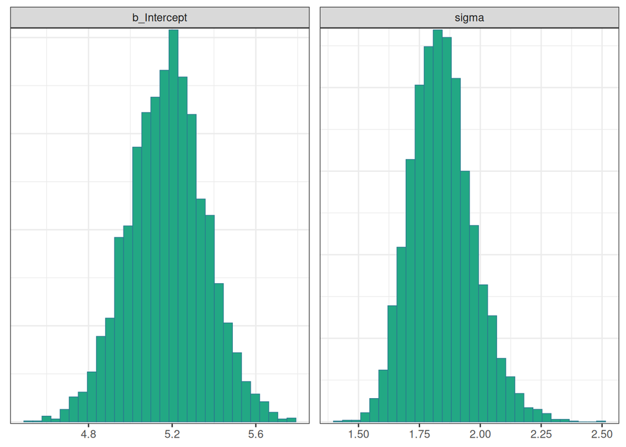

```r
mcmc_hist(normal_draws_brm, pars = c("b_Intercept", "sigma"))
```

### 1.3.3 Diagnostic summary

```r
rstan::check_hmc_diagnostics(normal_fit_brm$fit)
```

```
Divergences:
```

```
0 of 4000 iterations ended with a divergence.
```

```
Tree depth:
```

```
0 of 4000 iterations saturated the maximum tree depth of 10.
```

```
Energy:
```

```
E-BFMI indicated no pathological behavior.
```

# 2 Poisson model

$$y_i \sim \text{Poisson}(\lambda_i)$$

$$y_i \sim \operatorname{Poisson\_log}(\log \lambda_i)$$

## 2.1 Dummy data

```r
set.seed(123)
n <-  100
y <- rpois(n, lambda = 5)

pois_list <- list(
  y = y,
  N = n
)

pois_df <- tibble(
  y = y,
  N = n
)
```

## 2.2 Stan

`stan/pois.stan`

```stan
 data {
  int<lower=0> N;
  array[N] int<lower=0> y;
}

parameters {
  real<lower=0> lambda;
}

model {
  y ~ poisson(lambda);
  lambda ~ normal(0, 10);
}
```

`stan/pois_re.stan`

```stan
 data {
  int<lower=0> N;
  array[N] int<lower=0> y;
}

parameters {
  real log_lambda;
}

model {
  y ~ poisson_log(log_lambda);
  log_lambda ~ normal(0, 2.5);
}
```

```r
pois_mod <- cmdstan_model("stan/pois.stan")
pois_re_mod <- cmdstan_model("stan/pois_re.stan")
```

```r
pois_fit <- pois_mod$sample(
  data = pois_list,
  seed = 123,
  chains = 4,
  parallel_chains = 4,
  iter_warmup = 1000, # number of warmup iterations
  iter_sampling = 1000, # number of sampling iterations
  refresh = 0 # print update every 500 iters
)
```

```
Running MCMC with 4 parallel chains...

Chain 1 finished in 0.0 seconds.
Chain 2 finished in 0.0 seconds.
Chain 3 finished in 0.0 seconds.
Chain 4 finished in 0.0 seconds.

All 4 chains finished successfully.
Mean chain execution time: 0.0 seconds.
Total execution time: 0.2 seconds.
```

```r
pois_re_fit <- pois_re_mod$sample(
  data = pois_list,
  seed = 123,
  chains = 4,
  parallel_chains = 4,
  iter_warmup = 1000, # number of warmup iterations
  iter_sampling = 1000, # number of sampling iterations
  refresh = 0 # print update every 500 iters
)
```

```
Running MCMC with 4 parallel chains...

Chain 1 finished in 0.0 seconds.
Chain 2 finished in 0.0 seconds.
Chain 3 finished in 0.0 seconds.
Chain 4 finished in 0.0 seconds.

All 4 chains finished successfully.
Mean chain execution time: 0.0 seconds.
Total execution time: 0.2 seconds.
```

```r
pois_fit$summary()
```

```
# A tibble: 2 × 10
  variable   mean median    sd   mad     q5    q95  rhat ess_bulk ess_tail
  <chr>     <dbl>  <dbl> <dbl> <dbl>  <dbl>  <dbl> <dbl>    <dbl>    <dbl>
1 lp__     307.   308.   0.703 0.301 306.   308.    1.00    1920.    2392.
2 lambda     5.02   5.02 0.220 0.222   4.66   5.38  1.00    1495.    1693.
```

```r
pois_re_fit$summary()
```

```
# A tibble: 2 × 10
  variable     mean median     sd    mad     q5    q95  rhat ess_bulk ess_tail
  <chr>       <dbl>  <dbl>  <dbl>  <dbl>  <dbl>  <dbl> <dbl>    <dbl>    <dbl>
1 lp__       306.   306.   0.668  0.305  304.   306.    1.00    1946.    2201.
2 log_lambda   1.61   1.61 0.0440 0.0442   1.54   1.68  1.00    1681.    1763.
```

# 3 Multiple linear model

$$y_i \sim N(\beta_0 + \beta_1 x_{1i} + \beta_2 x_{2i}, \sigma)$$

or

$$y_i \sim N(\boldsymbol{\beta \cdot x}, \sigma)$$

```r
set.seed(123)
n <- 100
beta <- c(2, 1.2, -0.8)
x1 <- rnorm(n, mean = 0, sd = 1)
x2 <- rnorm(n, mean = 0, sd = 1)
sigma <- 0.4
y <- rnorm(n, mean = beta[1] + beta[2] * x1 + beta[3] * x2, sd = sigma)
```

```r
lm_list <- list(
  y = y,
  N = length(y),
  x = rbind(1, x1, x2)
)

lm_df <- tibble(
  y = y,
  N = length(y),
  x1 = x1,
  x2 = x2
)
```

## 3.1 Stan

`stan/lm.stan`

```stan
 data {
  int<lower=0> N;
  vector[N] y;
  matrix[3, N] x;
}

parameters {
  row_vector[3] beta;
  real<lower=0> sigma;
}

model {
  y ~ normal(beta * x, sigma);
  beta ~ normal(0, 2.5);
  sigma ~ cauchy(0, 2.5);
}
```

```r
lm_mod <- cmdstan_model("stan/lm.stan")

lm_fit <- lm_mod$sample(
  data = lm_list,
  seed = 123,
  chains = 4,
  parallel_chains = 4,
  iter_warmup = 1000, # number of warmup iterations
  iter_sampling = 1000, # number of sampling iterations
  refresh = 0 # don't print update
)
```

```
Running MCMC with 4 parallel chains...

Chain 1 finished in 0.0 seconds.
Chain 2 finished in 0.0 seconds.
Chain 3 finished in 0.0 seconds.
Chain 4 finished in 0.0 seconds.

All 4 chains finished successfully.
Mean chain execution time: 0.0 seconds.
Total execution time: 0.2 seconds.
```

```r
lm_fit$summary()
```

```
# A tibble: 5 × 10
  variable   mean median     sd    mad     q5    q95  rhat ess_bulk ess_tail
  <chr>     <dbl>  <dbl>  <dbl>  <dbl>  <dbl>  <dbl> <dbl>    <dbl>    <dbl>
1 lp__     44.6   44.9   1.48   1.27   41.6   46.3    1.00    1894.    2625.
2 beta[1]   2.05   2.05  0.0390 0.0386  1.99   2.12   1.00    3856.    3114.
3 beta[2]   1.15   1.15  0.0430 0.0414  1.08   1.22   1.00    4060.    2778.
4 beta[3]  -0.790 -0.789 0.0400 0.0394 -0.856 -0.726  1.00    4625.    3077.
5 sigma     0.386  0.384 0.0292 0.0291  0.342  0.437  1.00    3827.    2965.
```

## 3.2 brms

```r
lm_fit_brm <- brm(
  y ~ x1 + x2,
  family = gaussian(),
  data = lm_df,
  prior = c(
    prior(normal(0, 2.5), class = "Intercept"),
    prior(normal(0, 2.5), class = "b"),
    prior(cauchy(0, 2.5), class = "sigma")
  ),
  refresh = 0 # don't print update
)
summary(lm_fit_brm)
```

```
 Family: gaussian
  Links: mu = identity; sigma = identity
Formula: y ~ x1 + x2
   Data: lm_df (Number of observations: 100)
  Draws: 4 chains, each with iter = 2000; warmup = 1000; thin = 1;
         total post-warmup draws = 4000

Regression Coefficients:
          Estimate Est.Error l-95% CI u-95% CI Rhat Bulk_ESS Tail_ESS
Intercept     2.05      0.04     1.98     2.13 1.00     4258     2447
x1            1.15      0.04     1.06     1.23 1.00     4125     2515
x2           -0.79      0.04    -0.87    -0.71 1.00     4268     2820

Further Distributional Parameters:
      Estimate Est.Error l-95% CI u-95% CI Rhat Bulk_ESS Tail_ESS
sigma     0.39      0.03     0.34     0.45 1.00     4072     3208

Draws were sampled using sampling(NUTS). For each parameter, Bulk_ESS
and Tail_ESS are effective sample size measures, and Rhat is the potential
scale reduction factor on split chains (at convergence, Rhat = 1).
```

# 4 Varying intercepts

There is a power-law relationship ($y =\beta_0x^{\beta_1}$) between tree diameter (DBH) and tree maximum height, and the scaling factor $\beta_0$ varies among species.

$$\text{log}\; y_{ij} \sim N(\text{log}\; \beta_{0j} + \beta_1 x_{i}, \sigma)$$

$$\text{log}\; \beta_{0j} \sim N(\mu_0, \tau)$$

$$\mu_0 \sim N(0, 2.5)$$

$$\tau \sim \text{Half-Cauchy}(0, 1)$$

## 4.1 dummy data

- We simulate a dataset with 10 species and 20 trees per species.
- Each species has wood density (wd) values.

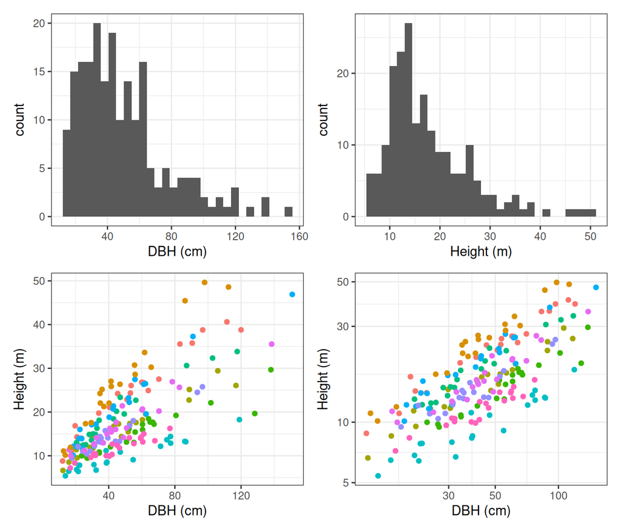

```r
set.seed(12345)

n_sp <- 10
n_rep <- 20
wd <- rnorm(n_sp, 0, 1)
gamma0 <- 0.6
gamma1 <- 0.1
sigma_y <- 0.1

b1_hat <- gamma1 * wd + gamma0
b1 <- rnorm(n_sp, b1_hat, 0.01)
log_b0 <- rnorm(n_sp, 0.55, 0.05)

# ---- simulate ----
allo_df <- tibble(
  sp     = factor(rep(paste0("sp", 1:n_sp), each = n_rep)),
  wd  = rep(wd, each = n_rep),
  # now log_xx ~ Normal(mean log‐dbh, sd
  log_xx = rnorm(n_sp * n_rep, mean = log(40), sd = 0.5)) |>
  mutate(
    # add observation‐level noise on log‐height
    log_y = rnorm(
      n(),
      log_b0[as.integer(sp)] + b1[as.integer(sp)] * log_xx,
      sigma_y),
    dbh = exp(log_xx),
    h = exp(log_y)) |>
  select(sp, wd, dbh, h)

dbh_hist <- allo_df |>
  ggplot(aes(dbh)) +
  geom_histogram() +
  xlab("DBH (cm)") +
  theme_bw() +
  theme(
    legend.position = "none",
    plot.title = element_text(size = 24)
    )

h_hist <- allo_df |>
  ggplot(aes(h)) +
  geom_histogram() +
  xlab("Height (m)") +
  theme_bw() +
  theme(
    legend.position = "none",
    plot.title = element_text(size = 24)
    )

p1 <- allo_df |>
  ggplot(aes(x = dbh, y = h, col = sp)) +
  geom_point() +
  xlab("DBH (cm)") +
  ylab(expression("Height (m)")) +
  theme_bw() +
  theme(
    legend.position = "none",
    plot.title = element_text(size = 24)
    )

p2 <- p1 +
  scale_x_log10() +
  scale_y_log10()


dbh_hist + h_hist + p1 + p2
```

```r
allo_list <- list(
  log_h = log(allo_df$h),
  log_dbh = log(allo_df$dbh),
  sp = as.integer(allo_df$sp),
  N = nrow(allo_df),
  J = allo_df$sp |> unique() |> length()
)
```

## 4.2 Stan

`stan/vint.stan`

```stan
 data {
  int<lower=1> N;               // total number of observations
  int<lower=1> J;               // number of species
  array[N] int<lower=1, upper=J> sp; // sp index
  vector[N] log_dbh;            // predictor: log(DBH)
  vector[N] log_h;              // response: log(height)
}

parameters {
  real        mu0;         // grand mean of log(mu₀)
  real<lower=0> tau;            // SD of species intercepts
  vector[J]   log_beta0;            // species‐level intercepts = log(β₀ⱼ)
  real        beta1;            // common slope on log(DBH)
  real<lower=0> sigma;          // residual SD
}

model {
  // Likelihood
  log_h ~ normal(log_beta0[sp] + beta1 * log_dbh, sigma);

  // Priors
  mu0 ~ normal(0, 2.5);
  tau      ~ cauchy(0, 1);
  log_beta0  ~ normal(mu0, tau);
  beta1    ~ normal(0, 2.5);
  sigma    ~ cauchy(0, 1);
}

// we need this for model selection
generated quantities {
  vector[N] log_lik;
  for (i in 1:N)
    log_lik[i] = normal_lpdf(log_h[i]
                    | log_beta0[sp[i]] + beta1 * log_dbh[i],
                      sigma);
}
```

```r
vint_mod <- cmdstan_model("stan/vint.stan")

vint_fit <- vint_mod$sample(
  data = allo_list,
  seed = 123,
  chains = 4,
  parallel_chains = 4,
  iter_warmup = 1000, # number of warmup iterations
  iter_sampling = 1000, # number of sampling iterations
  refresh = 0 # don't print update
)
```

```
Running MCMC with 4 parallel chains...
```

[output not shown]

[output not shown]

[output not shown]

[output not shown]

[output not shown]

[output not shown]

[output not shown]

[output not shown]

[output not shown]

[output not shown]

[output not shown]

[output not shown]

[output not shown]

[output not shown]

[output not shown]

```
Chain 1 finished in 0.2 seconds.
Chain 2 finished in 0.2 seconds.
Chain 3 finished in 0.2 seconds.
Chain 4 finished in 0.2 seconds.

All 4 chains finished successfully.
Mean chain execution time: 0.2 seconds.
Total execution time: 0.3 seconds.
```

```r
vint_fit$summary()
```

```
# A tibble: 215 × 10
   variable         mean   median     sd    mad      q5      q95  rhat ess_bulk
   <chr>           <dbl>    <dbl>  <dbl>  <dbl>   <dbl>    <dbl> <dbl>    <dbl>
 1 lp__         365.     366.     2.69   2.59   360.    369.      1.00    1185.
 2 mu0            0.483    0.484  0.119  0.114    0.285   0.679   1.00    1081.
 3 tau            0.332    0.314  0.0912 0.0781   0.221   0.503   1.00    1508.
 4 log_beta0[1]   0.782    0.782  0.0565 0.0569   0.689   0.875   1.01     416.
 5 log_beta0[2]   0.921    0.923  0.0544 0.0542   0.832   1.01    1.01     419.
 6 log_beta0[3]   0.440    0.442  0.0555 0.0564   0.349   0.531   1.01     413.
 7 log_beta0[4]   0.265    0.266  0.0580 0.0597   0.171   0.359   1.01     393.
 8 log_beta0[5]   0.620    0.621  0.0538 0.0535   0.531   0.708   1.01     420.
 9 log_beta0[6]  -0.0154  -0.0146 0.0545 0.0550  -0.105   0.0733  1.01     432.
10 log_beta0[7]   0.710    0.712  0.0545 0.0546   0.621   0.798   1.01     420.
# ℹ 205 more rows
# ℹ 1 more variable: ess_tail <dbl>
```

```r
vint_fit$diagnostic_summary()
```

```
$num_divergent
[1] 0 0 0 0

$num_max_treedepth
[1] 0 0 0 0

$ebfmi
[1] 1.0895940 0.9153065 1.0290711 1.0009129
```

## 4.3 brms

```r
priors <- c(
  prior(normal(0, 2.5), class = Intercept),
  prior(normal(0, 2.5),   class = b),
  prior(cauchy(0, 1),   class = sd),
  prior(cauchy(0, 1),   class = sigma)
)

vint_fit_brm <- brm(
  log(h) ~ log(dbh) + (1 | sp),
  family = gaussian(),
  data = allo_df,
  prior = priors,
  refresh = 0 # don't print update
)
summary(vint_fit_brm)
```

```
 Family: gaussian
  Links: mu = identity; sigma = identity
Formula: log(h) ~ log(dbh) + (1 | sp)
   Data: allo_df (Number of observations: 200)
  Draws: 4 chains, each with iter = 2000; warmup = 1000; thin = 1;
         total post-warmup draws = 4000

Multilevel Hyperparameters:
~sp (Number of levels: 10)
              Estimate Est.Error l-95% CI u-95% CI Rhat Bulk_ESS Tail_ESS
sd(Intercept)     0.34      0.10     0.20     0.58 1.01      638     1002

Regression Coefficients:
          Estimate Est.Error l-95% CI u-95% CI Rhat Bulk_ESS Tail_ESS
Intercept     0.47      0.12     0.22     0.71 1.00      662      834
logdbh        0.61      0.01     0.59     0.64 1.00     1996     1825

Further Distributional Parameters:
      Estimate Est.Error l-95% CI u-95% CI Rhat Bulk_ESS Tail_ESS
sigma     0.10      0.01     0.09     0.11 1.00     1983     1707

Draws were sampled using sampling(NUTS). For each parameter, Bulk_ESS
and Tail_ESS are effective sample size measures, and Rhat is the potential
scale reduction factor on split chains (at convergence, Rhat = 1).
```

```r
print(vint_fit_brm)
```

```
 Family: gaussian
  Links: mu = identity; sigma = identity
Formula: log(h) ~ log(dbh) + (1 | sp)
   Data: allo_df (Number of observations: 200)
  Draws: 4 chains, each with iter = 2000; warmup = 1000; thin = 1;
         total post-warmup draws = 4000

Multilevel Hyperparameters:
~sp (Number of levels: 10)
              Estimate Est.Error l-95% CI u-95% CI Rhat Bulk_ESS Tail_ESS
sd(Intercept)     0.34      0.10     0.20     0.58 1.01      638     1002

Regression Coefficients:
          Estimate Est.Error l-95% CI u-95% CI Rhat Bulk_ESS Tail_ESS
Intercept     0.47      0.12     0.22     0.71 1.00      662      834
logdbh        0.61      0.01     0.59     0.64 1.00     1996     1825

Further Distributional Parameters:
      Estimate Est.Error l-95% CI u-95% CI Rhat Bulk_ESS Tail_ESS
sigma     0.10      0.01     0.09     0.11 1.00     1983     1707

Draws were sampled using sampling(NUTS). For each parameter, Bulk_ESS
and Tail_ESS are effective sample size measures, and Rhat is the potential
scale reduction factor on split chains (at convergence, Rhat = 1).
```

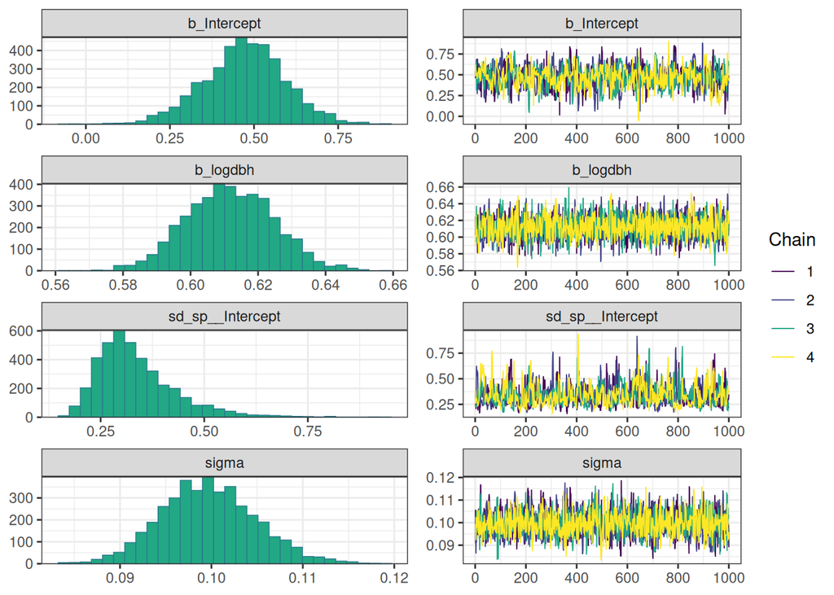

```r
plot(vint_fit_brm)
```

```
Using 10 posterior draws for ppc type 'dens_overlay' by default.
```

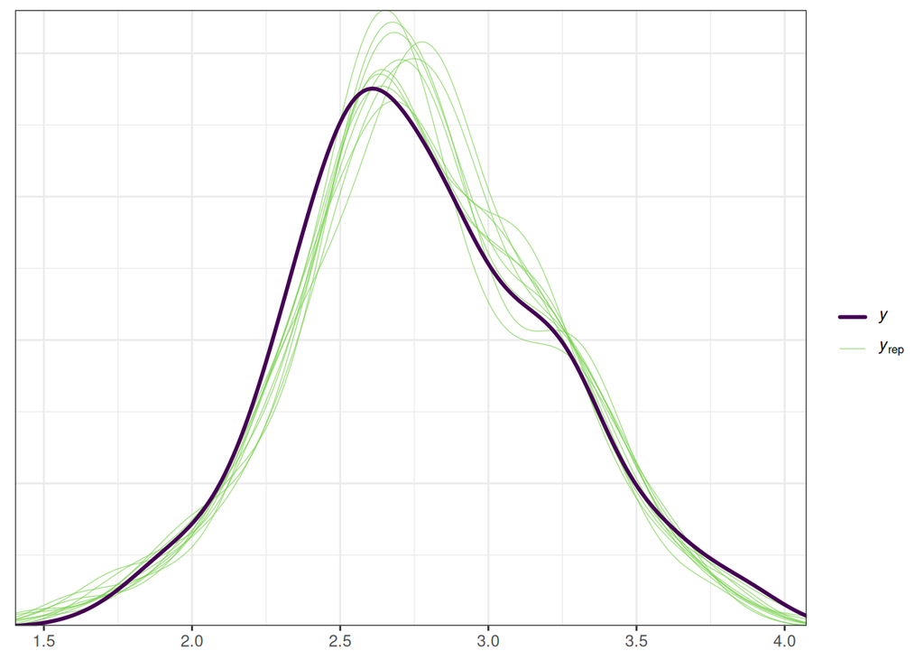

```r
pp_check(vint_fit_brm)
```

## 4.4 lme4

```r
vint_fit_lme <- lme4::lmer(
  log(h) ~ log(dbh) + (1 | sp),
  data = allo_df)

summary(vint_fit_lme)
```

```
Linear mixed model fit by REML ['lmerMod']
Formula: log(h) ~ log(dbh) + (1 | sp)
   Data: allo_df

REML criterion at convergence: -298.3

Scaled residuals:
     Min       1Q   Median       3Q      Max
-2.66966 -0.62316  0.04254  0.60122  2.28315

Random effects:
 Groups   Name        Variance Std.Dev.
 sp       (Intercept) 0.084434 0.29057
 Residual             0.009794 0.09897
Number of obs: 200, groups:  sp, 10

Fixed effects:
            Estimate Std. Error t value
(Intercept)  0.47916    0.10454   4.584
log(dbh)     0.61154    0.01314  46.525

Correlation of Fixed Effects:
         (Intr)
log(dbh) -0.472
```

# 5 Reparameterization for multilevel models

[Diagnosing Biased Inference with Divergences](https://betanalpha.github.io/assets/case_studies/divergences_and_bias.html#3_a_non-centered_eight_schools_implementation) by Michael Betancourt

## 5.1 Eight schools example

What is the effect of the treatment (a new education method) on students’ scores for each school and across schools?

| school | y | sigma |
| --- | --- | --- |
| School_1 | 28 | 15 |
| School_2 | 8 | 10 |
| School_3 | -3 | 16 |
| School_4 | 7 | 11 |
| School_5 | -1 | 9 |
| School_6 | 1 | 11 |
| School_7 | 18 | 10 |
| School_8 | 12 | 18 |

## 5.2 Centered parameterization

$$y_j \sim \mathcal{N}\bigl(\theta_j,\;\sigma_j\bigr)$$

$$\theta_j \sim \mathcal{N}\bigl(\mu,\;\tau \bigr)$$

$$\mu \sim \mathcal{N}\bigl(0,\;5 \bigr)$$

$$\tau \sim \text{Half-Cauchy}(0, 2.5)$$

*Note: $\sigma_j$ is known constant (i.e., data), we don’t have to estimate it.*

This parameterization is intuitive, but it often leads to convergence issues in hierarchical models.

## 5.3 Non-centered parameterization

$$\tilde{\theta_j} \sim \mathcal{N}\bigl(0,\;1 \bigr)$$

$$\theta_j = \mu + \tau \cdot \tilde{\theta_j}$$

In this parameterization, we introduce a new latent variable $\tilde{\theta_j}$ that is independent of the other parameters. This allows the sampler to explore the posterior more efficiently and avoids problems with convergence. We often use this parameterization when we have hierarchical models with varying intercepts or slopes.

# 6 Varying slopes and intercepts

There is a power-law relationship ($y =\beta_0 x^{\beta_1}$) between tree diameter (DBH) and tree maximum height, and both the scaling factor $\beta_0$ and the expoent $\beta_1$ vary among species.

$$\text{log}\; y_{ij} \sim N(\text{log}\; \beta_{0j} + \beta_{1j} x_{ij}, \sigma)$$

$$\begin{bmatrix}
\text{log}\; \beta_{0j} \\
\beta_{1j}
\end{bmatrix}
\sim
\mathrm{MVN}
\Biggl(
\begin{bmatrix}
\mu_{0} \\
\mu_{1}
\end{bmatrix},
\begin{bmatrix}
\sigma_{0}^2 & \rho \sigma_{0} \sigma_{1} \\
\rho \sigma_{0} \sigma_{1} & \sigma_{1}^2
\end{bmatrix}
\Biggr)$$

## 6.1 Centered parameterization

$$\boldsymbol\mu \sim N(0, 2.5)$$

$$\boldsymbol\Sigma \sim \mathcal{W}^{-1}_p(\nu,\,\Psi)$$

This parameterization using inverse-whishart distribution $\mathcal{W}^{-1}$ is **not recommended** for hierarchical models with varying slopes and intercepts.

## 6.2 Non-Centered parameterization

[Optimization through Cholesky factorization](https://mc-stan.org/docs/stan-users-guide/regression.html#hierarchical-priors.section)

$$\boldsymbol z_j \sim \mathcal{N}(\mathbf0,\,I_2)$$
$$\begin{pmatrix}\log\beta_{0j}\\[3pt]\beta_{1j}\end{pmatrix}
= \boldsymbol\mu + L\, \boldsymbol z_j$$

Some linear algebra (Cholesk decomposition):

$$\Sigma \;=\;L\,L^\top
\;=\;\bigl[\mathrm{diag}(\tau)\,L_\Omega\bigr]\,
\bigl[L_\Omega^\top\,\mathrm{diag}(\tau)\bigr]
\;=\;\mathrm{diag}(\tau)\,\Omega\,\mathrm{diag}(\tau).$$

$$L_\Omega \sim \mathrm{LKJ\_Corr\_Cholesky}(2) \quad \text{or} \quad \Omega \sim \mathrm{LKJ\_Corr}(2)$$
$$\tau_i \sim \mathrm{Half\text{-}Cauchy}(0,1)$$

Rather than sampling the correlation matix $\Omega$ directly, sampling the Cholesky factor $L_\Omega$ is computationally more efficient and numerically stable.

In the LKJ() prior:

- $\eta$ = 1 indicate flat prior (uniform distribution) over correlation matrices.
- $\eta$ > 1 indicate weaker correlations.

We usually use $\eta$ = 2 because we assume at leat weak correlations among the parameters, but still allow mooderate to strong cvorrelations.

## 6.3 Stan

`stan/vslope.stan`

```r
cmdstanr::set_cmdstan_path("/opt/cmdstan/cmdstan-2.36.0")
```

```
CmdStan path set to: /opt/cmdstan/cmdstan-2.36.0
```

```stan
 data {
  int<lower=0> N;              // num individuals
  int<lower=1> K;              // num ind predictors
  int<lower=1> J;              // num groups
  array[N] int<lower=1, upper=J> jj;  // group for individual
  int<lower=1> L;              // number of group-level predictors
  matrix[N, K] x;              // individual predictors
  matrix[L, J] u;              // group predictors
  vector[N] y;                 // outcomes
}

parameters {
  matrix[K, L] gamma;          // coefficients across groups
  real<lower=0> sigma;         // prediction error scale
  vector<lower=0>[K] tau;      // prior scale
  matrix[K, J] z;
  cholesky_factor_corr[K] L_Omega;
}

transformed parameters {
  matrix[K, J] beta;
  beta = gamma * u + diag_pre_multiply(tau, L_Omega) * z;
}

model {
  to_vector(z) ~ std_normal();
  tau ~ cauchy(0, 2.5);
  L_Omega ~ lkj_corr_cholesky(2);
  to_vector(gamma) ~ normal(0, 2.5);
  for (n in 1:N) {
    y[n] ~ normal(x[n, ] * beta[, jj[n]], sigma);
  }
}
```

```r
allo_vslope_list <- list(
  y = log(allo_df$h),
  x = cbind(1, log(allo_df$dbh)),
  jj = as.integer(allo_df$sp),
  N = nrow(allo_df),
  K = 2, # number of predictors (intercept + slope)
  J = allo_df$sp |> unique() |> length(),
  L = 1 # number of group-level predictors (intercept)
)
allo_vslope_list$u <- matrix(1, nrow = allo_vslope_list$L, ncol = allo_vslope_list$J)
```

```r
vslope_mod <- cmdstan_model("stan/vslope.stan")

vslope_fit <- vslope_mod$sample(
  data = allo_vslope_list,
  seed = 1234,
  chains = 4,
  parallel_chains = 4,
  iter_warmup = 1000, # number of warmup iterations
  iter_sampling = 1000, # number of sampling iterations
  adapt_delta = 0.95, # increase adapt_delta to avoid divergent transitions
  max_treedepth = 15, # increase max_treedepth to avoid max treedepth errors
  refresh = 0 # don't print update
)
```

```
Running MCMC with 4 parallel chains...
```

[output not shown]

[output not shown]

[output not shown]

[output not shown]

[output not shown]

[output not shown]

[output not shown]

[output not shown]

[output not shown]

[output not shown]

[output not shown]

[output not shown]

[output not shown]

[output not shown]

[output not shown]

[output not shown]

[output not shown]

[output not shown]

[output not shown]

[output not shown]

[output not shown]

[output not shown]

[output not shown]

[output not shown]

[output not shown]

[output not shown]

[output not shown]

[output not shown]

[output not shown]

[output not shown]

[output not shown]

[output not shown]

[output not shown]

[output not shown]

[output not shown]

[output not shown]

[output not shown]

[output not shown]

[output not shown]

[output not shown]

[output not shown]

[output not shown]

[output not shown]

[output not shown]

[output not shown]

[output not shown]

[output not shown]

[output not shown]

[output not shown]

[output not shown]

[output not shown]

[output not shown]

[output not shown]

[output not shown]

[output not shown]

[output not shown]

[output not shown]

[output not shown]

[output not shown]

[output not shown]

[output not shown]

[output not shown]

[output not shown]

[output not shown]

[output not shown]

[output not shown]

[output not shown]

[output not shown]

[output not shown]

[output not shown]

[output not shown]

[output not shown]

[output not shown]

[output not shown]

[output not shown]

[output not shown]

[output not shown]

[output not shown]

[output not shown]

[output not shown]

[output not shown]

[output not shown]

[output not shown]

[output not shown]

[output not shown]

[output not shown]

[output not shown]

[output not shown]

[output not shown]

[output not shown]

[output not shown]

[output not shown]

[output not shown]

[output not shown]

[output not shown]

[output not shown]

[output not shown]

[output not shown]

[output not shown]

[output not shown]

[output not shown]

[output not shown]

[output not shown]

[output not shown]

[output not shown]

```
Chain 1 finished in 6.5 seconds.
Chain 4 finished in 6.4 seconds.
Chain 2 finished in 6.7 seconds.
Chain 3 finished in 6.9 seconds.

All 4 chains finished successfully.
Mean chain execution time: 6.6 seconds.
Total execution time: 6.9 seconds.
```

```r
vslope_fit$summary()
```

```
# A tibble: 50 × 10
   variable       mean   median      sd     mad        q5     q95  rhat ess_bulk
   <chr>         <dbl>    <dbl>   <dbl>   <dbl>     <dbl>   <dbl> <dbl>    <dbl>
 1 lp__       359.     360.     4.45    4.44    352.      366.     1.00    1247.
 2 gamma[1,1]   0.500    0.500  0.0535  0.0530    0.414     0.584  1.00    3733.
 3 gamma[2,1]   0.605    0.606  0.0327  0.0292    0.552     0.657  1.00    1904.
 4 sigma        0.0924   0.0921 0.00477 0.00468   0.0850    0.101  1.00    5112.
 5 tau[1]       0.0702   0.0596 0.0540  0.0494    0.00624   0.170  1.00    2080.
 6 tau[2]       0.0871   0.0820 0.0280  0.0244    0.0524    0.138  1.00    1475.
 7 z[1,1]       0.609    0.665  0.883   0.878    -0.911     1.98   1.00    2339.
 8 z[2,1]       0.667    0.699  0.654   0.594    -0.430     1.67   1.00    1852.
 9 z[1,2]       0.243    0.284  0.982   0.990    -1.43      1.79   1.00    1445.
10 z[2,2]       1.30     1.32   0.668   0.627     0.193     2.34   1.00    1879.
# ℹ 40 more rows
# ℹ 1 more variable: ess_tail <dbl>
```

```r
vslope_fit$diagnostic_summary()
```

```
$num_divergent
[1] 0 0 0 0

$num_max_treedepth
[1] 0 0 0 0

$ebfmi
[1] 0.7886014 0.8163567 0.7869412 0.8183356
```

## 6.4 brms

```r
priors <- c(
  prior(normal(0, 2.5), class = Intercept),
  prior(normal(0, 2.5),   class = b),
  prior(lkj(2), class = cor),                # Ω ~ LKJ(2)
  prior(cauchy(0, 1),   class = sigma)
)

slope_fit_brm <- brm(
  log(h) ~ log(dbh) + (1 + log(dbh) | sp),
  family = gaussian(),
  data = allo_df,
  prior = priors,
  refresh = 0, # don't print update
  control = list(
    adapt_delta  = 0.95,  # default is 0.8
    max_treedepth = 15    # default is 10
  )
)
```

```r
summary(slope_fit_brm)
```

```
 Family: gaussian
  Links: mu = identity; sigma = identity
Formula: log(h) ~ log(dbh) + (1 + log(dbh) | sp)
   Data: allo_df (Number of observations: 200)
  Draws: 4 chains, each with iter = 2000; warmup = 1000; thin = 1;
         total post-warmup draws = 4000

Multilevel Hyperparameters:
~sp (Number of levels: 10)
                      Estimate Est.Error l-95% CI u-95% CI Rhat Bulk_ESS
sd(Intercept)             0.07      0.06     0.00     0.21 1.00     1645
sd(logdbh)                0.09      0.03     0.05     0.15 1.00     1414
cor(Intercept,logdbh)     0.09      0.43    -0.73     0.80 1.01      690
                      Tail_ESS
sd(Intercept)             1621
sd(logdbh)                2246
cor(Intercept,logdbh)     1052

Regression Coefficients:
          Estimate Est.Error l-95% CI u-95% CI Rhat Bulk_ESS Tail_ESS
Intercept     0.50      0.06     0.39     0.61 1.00     4128     2989
logdbh        0.60      0.03     0.55     0.66 1.00     1900     2289

Further Distributional Parameters:
      Estimate Est.Error l-95% CI u-95% CI Rhat Bulk_ESS Tail_ESS
sigma     0.09      0.00     0.08     0.10 1.00     5442     2654

Draws were sampled using sampling(NUTS). For each parameter, Bulk_ESS
and Tail_ESS are effective sample size measures, and Rhat is the potential
scale reduction factor on split chains (at convergence, Rhat = 1).
```

## 6.5 lme4

```r
slope_fit_lme <- lme4::lmer(
  log(h) ~ log(dbh) + (1 + log(dbh) | sp),
  data = allo_df)
```

```
boundary (singular) fit: see help('isSingular')
```

**Not convergent!**

```r
summary(slope_fit_lme)
```

```
Linear mixed model fit by REML ['lmerMod']
Formula: log(h) ~ log(dbh) + (1 + log(dbh) | sp)
   Data: allo_df

REML criterion at convergence: -327.2

Scaled residuals:
     Min       1Q   Median       3Q      Max
-3.14307 -0.63987  0.08714  0.61696  3.03735

Random effects:
 Groups   Name        Variance Std.Dev. Corr
 sp       (Intercept) 0.001326 0.03641
          log(dbh)    0.004607 0.06787  1.00
 Residual             0.008397 0.09164
Number of obs: 200, groups:  sp, 10

Fixed effects:
            Estimate Std. Error t value
(Intercept)  0.49980    0.04759   10.50
log(dbh)     0.60637    0.02468   24.57

Correlation of Fixed Effects:
         (Intr)
log(dbh) -0.264
optimizer (nloptwrap) convergence code: 0 (OK)
boundary (singular) fit: see help('isSingular')
```

# 7 Varying slopes and intercepts, and group-level predictors

There is a power-law relationship ($y =\beta_0 x^{\beta_1}$) between tree diameter (DBH) and tree maximum height, and both the scaling factor $\beta_0$ and the expoent $\beta_1$ vary among species. Those species variation can be explained by wood density (group-level predictor: $u$) of each species.

$$\text{log}\; y_{ij} \sim N(\text{log}\; \beta_{0j} + \beta_{1j} x_{ij}, \sigma)$$

$$\begin{bmatrix}
\text{log}\; \beta_{0j} \\
\beta_{1j}
\end{bmatrix}
\sim
\mathrm{MVN}
\Biggl(
\underbrace{
\begin{bmatrix}
\gamma_{0}^{(\beta_0)} + \gamma_{1}^{(\beta_0)}u_{j} \\
\gamma_{0}^{(\beta_1)} + \gamma_{1}^{(\beta_1)}u_{j}
\end{bmatrix}}_{\text{mean depends on }u_j},
\begin{bmatrix}
\sigma_{0}^2 & \rho \sigma_{0} \sigma_{1} \\
\rho \sigma_{0} \sigma_{1} & \sigma_{1}^2
\end{bmatrix}
\Biggr)$$

The rest of part is the same as the section Varying slopes and intercepts.

```r
allo_vslope_list$L <- 2 # number of group-level predictors (intercept and wd)
allo_vslope_list$u <- matrix(1, nrow = allo_vslope_list$L, ncol = allo_vslope_list$J)
```

```r
vgrp_fit <- vslope_mod$sample(
  data = allo_vslope_list,
  seed = 1234,
  chains = 4,
  parallel_chains = 4,
  iter_warmup = 1000, # number of warmup iterations
  iter_sampling = 1000, # number of sampling iterations
  adapt_delta = 0.95, # increase adapt_delta to avoid divergent transitions
  max_treedepth = 15, # increase max_treedepth to avoid max treedepth errors
  refresh = 0 # don't print update
)
```

```
Running MCMC with 4 parallel chains...
```

[output not shown]

[output not shown]

[output not shown]

[output not shown]

[output not shown]

[output not shown]

[output not shown]

[output not shown]

[output not shown]

[output not shown]

[output not shown]

[output not shown]

[output not shown]

[output not shown]

[output not shown]

[output not shown]

[output not shown]

[output not shown]

[output not shown]

[output not shown]

[output not shown]

[output not shown]

[output not shown]

[output not shown]

[output not shown]

[output not shown]

[output not shown]

[output not shown]

[output not shown]

[output not shown]

[output not shown]

[output not shown]

[output not shown]

[output not shown]

[output not shown]

[output not shown]

[output not shown]

[output not shown]

[output not shown]

[output not shown]

[output not shown]

[output not shown]

[output not shown]

[output not shown]

[output not shown]

[output not shown]

[output not shown]

[output not shown]

[output not shown]

[output not shown]

[output not shown]

[output not shown]

[output not shown]

[output not shown]

[output not shown]

[output not shown]

[output not shown]

[output not shown]

[output not shown]

[output not shown]

[output not shown]

[output not shown]

[output not shown]

[output not shown]

[output not shown]

[output not shown]

[output not shown]

[output not shown]

[output not shown]

[output not shown]

[output not shown]

[output not shown]

[output not shown]

[output not shown]

[output not shown]

[output not shown]

[output not shown]

[output not shown]

[output not shown]

[output not shown]

[output not shown]

[output not shown]

[output not shown]

[output not shown]

[output not shown]

[output not shown]

[output not shown]

[output not shown]

[output not shown]

[output not shown]

[output not shown]

[output not shown]

[output not shown]

[output not shown]

[output not shown]

[output not shown]

[output not shown]

[output not shown]

[output not shown]

[output not shown]

[output not shown]

[output not shown]

[output not shown]

[output not shown]

[output not shown]

[output not shown]

[output not shown]

[output not shown]

[output not shown]

[output not shown]

[output not shown]

[output not shown]

[output not shown]

[output not shown]

[output not shown]

[output not shown]

[output not shown]

[output not shown]

[output not shown]

[output not shown]

[output not shown]

[output not shown]

[output not shown]

[output not shown]

[output not shown]

[output not shown]

[output not shown]

[output not shown]

[output not shown]

[output not shown]

[output not shown]

[output not shown]

[output not shown]

[output not shown]

[output not shown]

[output not shown]

[output not shown]

[output not shown]

[output not shown]

[output not shown]

[output not shown]

[output not shown]

[output not shown]

[output not shown]

[output not shown]

[output not shown]

[output not shown]

[output not shown]

[output not shown]

[output not shown]

[output not shown]

[output not shown]

[output not shown]

[output not shown]

[output not shown]

[output not shown]

[output not shown]

[output not shown]

[output not shown]

[output not shown]

```
Chain 2 finished in 158.0 seconds.
Chain 4 finished in 159.6 seconds.
Chain 3 finished in 172.7 seconds.
Chain 1 finished in 182.2 seconds.

All 4 chains finished successfully.
Mean chain execution time: 168.1 seconds.
Total execution time: 182.3 seconds.
```

```r
vgrp_fit$summary()
```

```
# A tibble: 52 × 10
   variable       mean   median      sd     mad        q5     q95  rhat ess_bulk
   <chr>         <dbl>    <dbl>   <dbl>   <dbl>     <dbl>   <dbl> <dbl>    <dbl>
 1 lp__       359.     359.     4.58    4.47    351.      366.     1.01    1100.
 2 gamma[1,1]   0.217    0.225  1.80    1.81     -2.75      3.19   1.00    3197.
 3 gamma[2,1]   0.266    0.237  1.79    1.73     -2.70      3.29   1.00    3238.
 4 gamma[1,2]   0.283    0.267  1.80    1.80     -2.68      3.24   1.00    3184.
 5 gamma[2,2]   0.341    0.365  1.79    1.72     -2.67      3.31   1.00    3233.
 6 sigma        0.0923   0.0920 0.00476 0.00485   0.0850    0.101  1.00    5985.
 7 tau[1]       0.0715   0.0588 0.0565  0.0524    0.00504   0.177  1.00    1922.
 8 tau[2]       0.0893   0.0842 0.0288  0.0235    0.0537    0.143  1.00    1591.
 9 z[1,1]       0.579    0.649  0.901   0.903    -1.01      1.91   1.00    2505.
10 z[2,1]       0.658    0.703  0.654   0.595    -0.476     1.64   1.00    1993.
# ℹ 42 more rows
# ℹ 1 more variable: ess_tail <dbl>
```

```r
vgrp_fit$diagnostic_summary()
```

```
$num_divergent
[1] 0 0 0 0

$num_max_treedepth
[1] 0 0 0 0

$ebfmi
[1] 0.8748743 0.7876773 0.8130332 0.7948173
```

## 7.1 brms

```r
priors <- c(
  prior(normal(0, 2.5), class = Intercept),
  prior(normal(0, 2.5),   class = b),
  prior(lkj(2), class = cor),                # Ω ~ LKJ(2)
  prior(cauchy(0, 1),   class = sigma)
)

vgrp_fit_brm <- brm(
  log(h) ~ log(dbh) * wd + (1 + log(dbh) | sp),
  family = gaussian(),
  data = allo_df,
  prior = priors,
  refresh = 0, # don't print update
  control = list(
    adapt_delta  = 0.95,  # default is 0.8
    max_treedepth = 15    # default is 10
  )
)
```

```r
summary(vgrp_fit_brm)
```

```
 Family: gaussian
  Links: mu = identity; sigma = identity
Formula: log(h) ~ log(dbh) * wd + (1 + log(dbh) | sp)
   Data: allo_df (Number of observations: 200)
  Draws: 4 chains, each with iter = 2000; warmup = 1000; thin = 1;
         total post-warmup draws = 4000

Multilevel Hyperparameters:
~sp (Number of levels: 10)
                      Estimate Est.Error l-95% CI u-95% CI Rhat Bulk_ESS
sd(Intercept)             0.09      0.07     0.00     0.25 1.00     1670
sd(logdbh)                0.08      0.03     0.04     0.15 1.00     1423
cor(Intercept,logdbh)     0.12      0.43    -0.70     0.85 1.00     1151
                      Tail_ESS
sd(Intercept)             1744
sd(logdbh)                2240
cor(Intercept,logdbh)     1704

Regression Coefficients:
          Estimate Est.Error l-95% CI u-95% CI Rhat Bulk_ESS Tail_ESS
Intercept     0.50      0.06     0.39     0.62 1.00     3519     3090
logdbh        0.60      0.03     0.53     0.66 1.00     1664     1679
wd            0.03      0.07    -0.12     0.17 1.00     4033     2436
logdbh:wd    -0.05      0.04    -0.13     0.03 1.00     2557     1673

Further Distributional Parameters:
      Estimate Est.Error l-95% CI u-95% CI Rhat Bulk_ESS Tail_ESS
sigma     0.09      0.00     0.08     0.10 1.00     5679     3075

Draws were sampled using sampling(NUTS). For each parameter, Bulk_ESS
and Tail_ESS are effective sample size measures, and Rhat is the potential
scale reduction factor on split chains (at convergence, Rhat = 1).
```

## 7.2 lme4

```r
grp_fit_lme <- lme4::lmer(
  log(h) ~ log(dbh) * wd + (1 + log(dbh) | sp),
  data = allo_df)
```

```
boundary (singular) fit: see help('isSingular')
```

# 8 References

- Betancourt, M. (2017). [Diagnosing Biased Inference with Divergences](https://betanalpha.github.io/assets/case_studies/divergences_and_bias.html#3_a_non-centered_eight_schools_implementation).
- [Gelman, A. et al. Bayesian Data Analysis, Third Edition. (Chapman & Hall/CRC, 2013)](http://www.stat.columbia.edu/~gelman/book/)
- [Stan User’s Guide](https://mc-stan.org/docs/stan-users-guide/index.html)
- [Stan Functions Reference](https://mc-stan.org/docs/functions-reference/index.html)